# Grupo Bimbo - Prevendo Demanda de Estoque com Base em Vendas

Verificando as informações das variáveis.

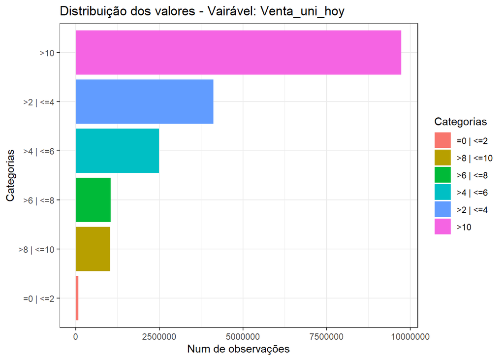

```r
# Unidades vendidas.
categorias('Venta_uni_hoy')
```

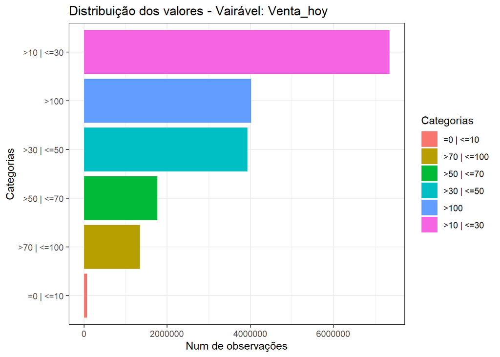

```r
# Valor total da venda.
categorias('Venta_hoy')
```

Aqui conseguimos notar que a maior parte das vendas dos produtos está entre de 11 à 30 pesos.

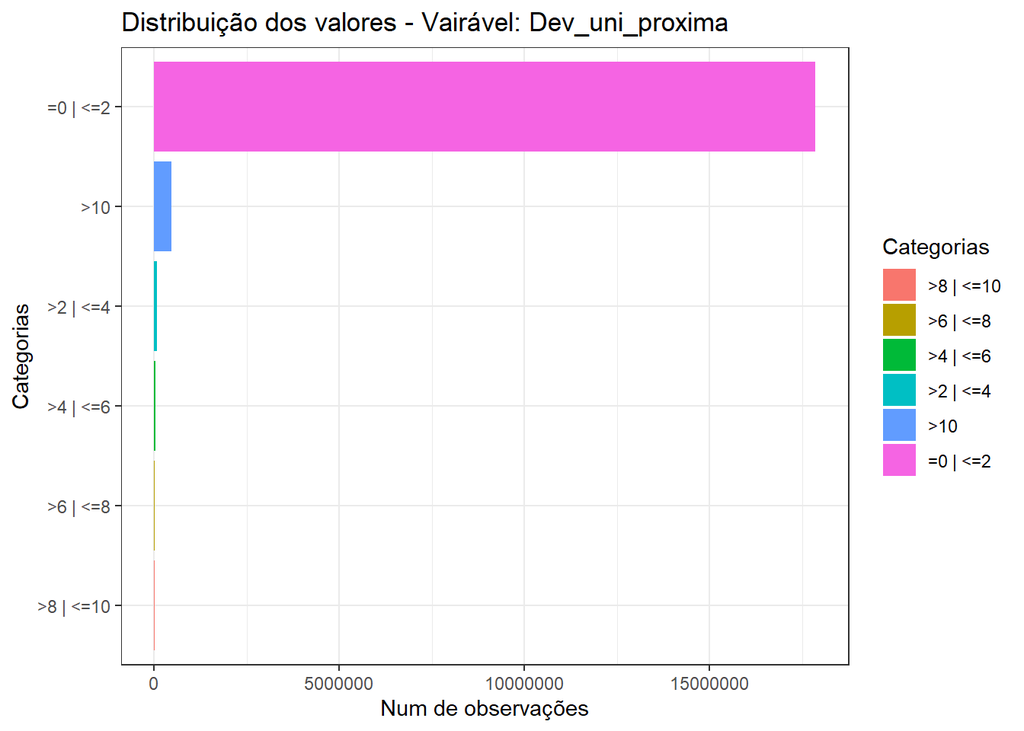

```r
# Unidades devolvidas.
categorias('Dev_uni_proxima')
```

Aqui vemos que entre os produtos devolvidos as unidades estão entre 0 e 2 undiades.

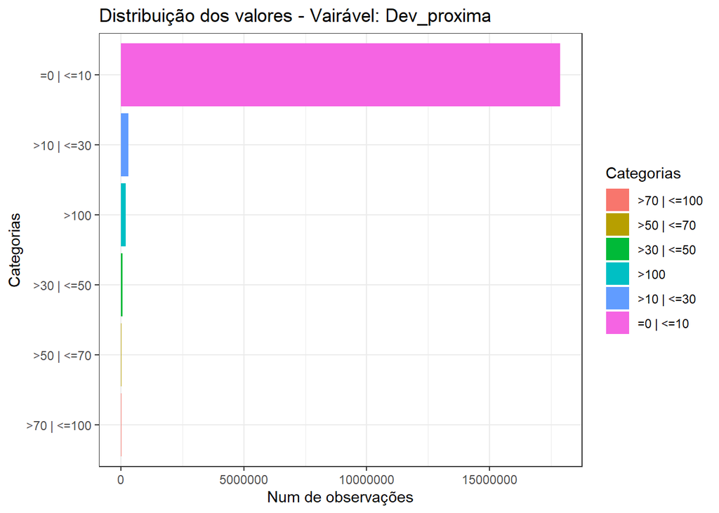

```r
# Valor das devoluções.
categorias('Dev_proxima')
```

Em relação ao valor de devolução podemos ver que praticamente quase todos estão entre 0 e 10 pesos.

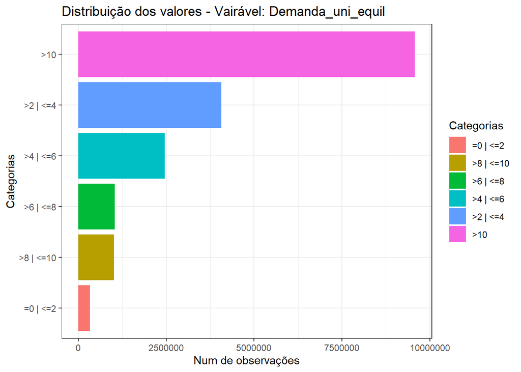

```r
# Demanda ajustada.
categorias('Demanda_uni_equil')
```

Aqui conseguimos notar que na maior parte da demanda ajusta está em produtos acima de 10 unidades.

```r
# Removendo o subset das variáveis numéricas.
rm(vars_numericas)
gc()
```

Vejamos algumas informações de tendência central e dispersão.

Criaremos uma função para realizar essas análises.

```
## [1] "Variável: Venta_uni_hoy"
##
##  Venta_uni_hoy
##  Min.   :   0.00
##  1st Qu.:   2.00
##  Median :   3.00
##  Mean   :   7.32
##  3rd Qu.:   7.00
##  Max.   :5000.00
##
##
## [1] "Moda: 2"
##
## [1] "Desvio padrão: 21.94"
##
## [1] "Coeficiente de variação: 299.68"
##
## Intervalo de confiança de 95%
##  7 7
##
## Boxplot Criado...
##
##
## ---
##
##
## [1] "Variável: Venta_hoy"
##
##    Venta_hoy
##  Min.   :     0.0
##  1st Qu.:    16.8
##  Median :    30.0
##  Mean   :    68.6
##  3rd Qu.:    56.1
##  Max.   :382694.4
##
##
## [1] "Moda: 16.76"
##
## [1] "Desvio padrão: 327.55"
```

[output cut: 47 more lines]

```
##
##
## [1] "Moda: 0"
##
## [1] "Desvio padrão: 41.41"
##
## [1] "Coeficiente de variação: 3308.46"
##
## Intervalo de confiança de 95%
##  1 1
##
## Boxplot Criado...
##
##
## ---
```

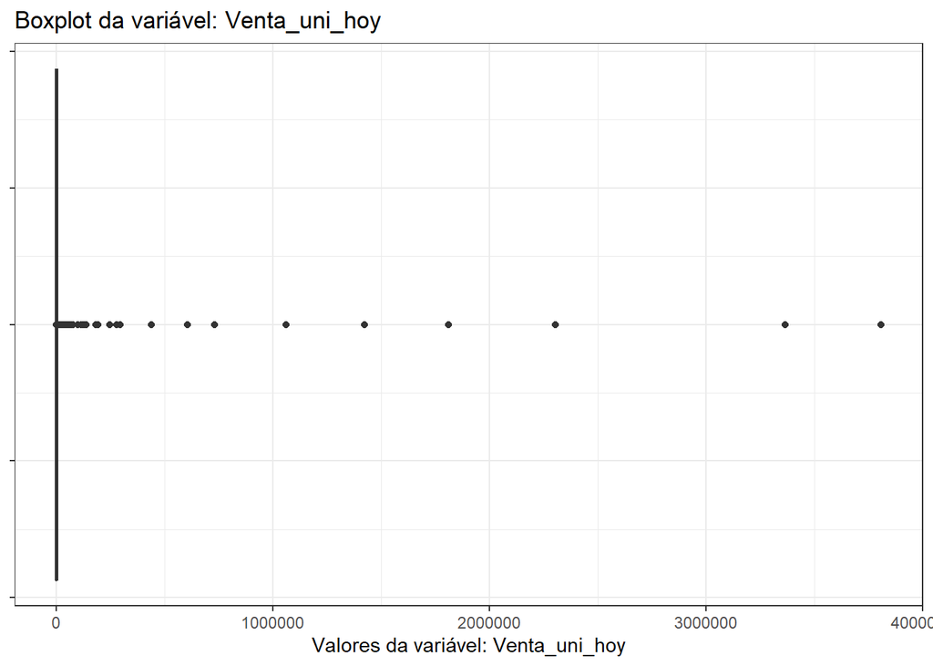

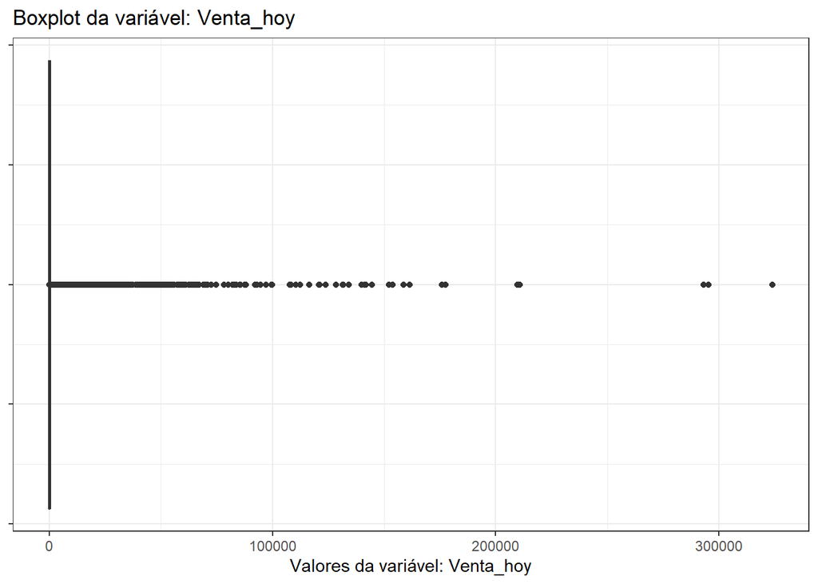

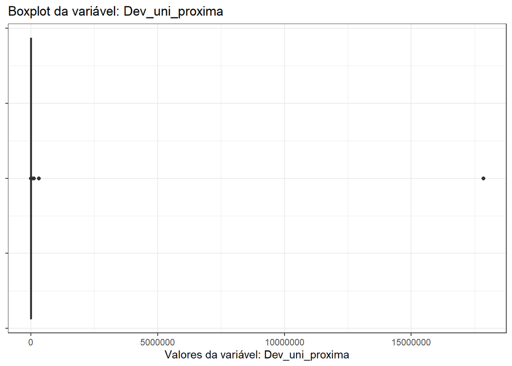

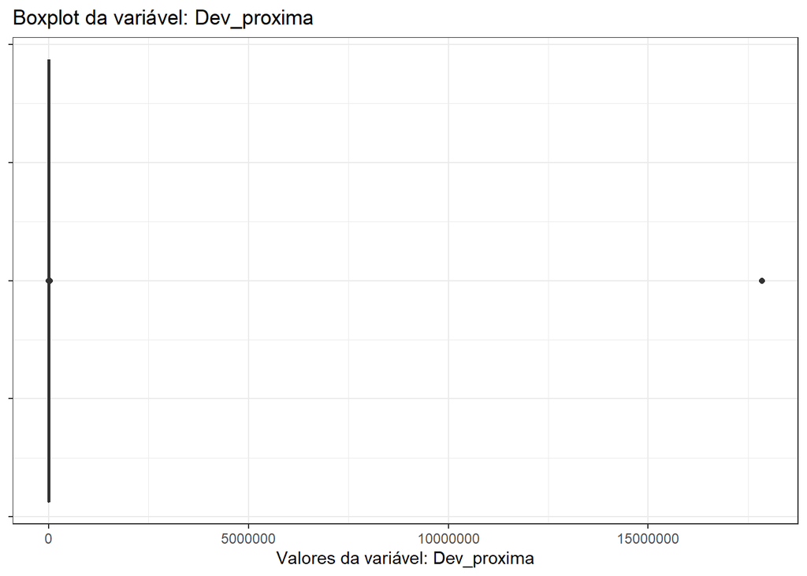

```r
# Função para análises estatítisca.
analises_numericas <- function(colunas){
  lapply(colunas, function(coluna){
    if (is.numeric(dados[[coluna]])){

      print(paste('Variável:', coluna))
      cat('\n')

      # Resumo da variável
      print(summary(dados[, coluna, with=F]))
      cat('\n\n')

      # Verificando a moda do conjunto de dados.
      vetor <- table(dados[, coluna, with=F])
      print(paste('Moda:', names(vetor[vetor == max(vetor)])))
      cat('\n')

      # Desvio padrão.
      print(paste('Desvio padrão:', round(sd(dados[[coluna]]), digits = 2)))
      cat('\n')

      # Coeficiente de variação.
      print(paste('Coeficiente de variação:', round((sd(dados[[coluna]])/mean(dados[[coluna]])*100), digits = 2)))
      cat('\n')

      # Intervalo de confiança.
      erro_padrao <- sd(dados[[coluna]]) / sqrt(nrow(dados))
      cat('Intervalo de confiança de 95%\n', round(c(mean(dados[[coluna]]) - (1.96 * erro_padrao), mean(dados[[coluna]]) + (1.96 * erro_padrao))))
      cat('\n\n')

      cat('Boxplot Criado...')
      cat('\n\n\n')
      cat('---')
      cat('\n\n\n')

      # Boxplot para visualização das informações.
      dados[, .(repeticoes = .N), by = coluna] %>% ggplot(aes(x = repeticoes)) +
        geom_boxplot(fill = '#0068ff') + theme_bw() + theme(axis.text.y = element_blank()) + xlab(paste('Valores da variável:', coluna)) + ggtitle(paste('Boxplot da variável:', coluna))

    }
  })
}

# Aplicando a função.
analises_numericas(names(dados[, -'Demanda_uni_equil']))
```

Também é possível notar que a maioria dos dados estão num intervalo bem pequeno, devido ao alto valor dos outliers quase não vemos a caixa dos boxplots.

Podemos ver que existem preços totalmente desproporcionais com as demais observações.

Tanto a variável **Dev_uni_proxima** quanto a **Dev_proxima** apresentam um outliers com valor imensamente altos, acima de 15.000.000.

Vamos analisar os outliers de cada variável. Criaremos objetos contendo os outliers de cada variável.

```r
# Criando os objetos com outliers.
for (i in names(dados[, numericas, with=F][,-5])){

  assign(paste('outliers_', i, sep = ''), boxplot(dados[, i, with=F], plot=FALSE)$out)

}
```

Verificando os outliers.

```r
# Criando uma amostra contendo os outliers da variável Venta_uni_hoy.
tb_Venta_uni_hoy <- dados[Venta_uni_hoy %in% outliers_Venta_uni_hoy]

# Verificando o percentual em relação ao conjunto de dados.
tb_Venta_uni_hoy[, .(Num_registros = .N,
                 Percentual = round(.N / nrow(dados) * 100, digits = 4))]
```

```
##    Num_registros Percentual
## 1:       1833695      9.918
```

```r
# Verificando algumas linhas dos outliers e ordenando em ordem decrescente pelas unidades vendidas.
tb_Venta_uni_hoy[order(-Venta_uni_hoy)]
```

```
##          Semana Canal_ID Ruta_SAK Venta_uni_hoy Venta_hoy Dev_uni_proxima
##       1:      3        8     5702          5000  34600.00               0
##       2:      6       11     3901          4999  31243.75               0
##       3:      8       11     3938          4997  39976.00               0
##       4:      8       11     3938          4975  35820.00               0
##       5:      6        8     5702          4966  78661.44               0
##      ---
## 1833691:      8        4     6638            15    126.00               0
## 1833692:      3        1     4426            15     79.20               0
## 1833693:      3        1     2172            15    116.70               0
## 1833694:      5        4     6605            15     62.25               0
## 1833695:      8        1     2107            15     93.75               0
##          Dev_proxima Demanda_uni_equil                  Nome_cliente
##       1:           0              5000          CERESO DEL HONGO TKT
##       2:           0              4999                   PCE FOXCONN
```

[output cut: 33 more lines]

Podemos ver que na semana 3, o cliente **Cereso Del Holgo TKT** vendeu 5.000 unidades do produto **Triki Trakes**, na ciadade de **Tecate**, em **Baja California Norte**.

Colado a ele na semana 6 o cliente **PCE Foxconn** vendeu 4.999 unidades do produto **Galleta Gansito**, na cidade de **Juarez** em **Chihuahua**.

De contrapartida podemos ver que os últimos 5 clientes venderam apenas 15 unidades de cada um dos produtos.

```r
# Removeremos os outliers da **Venta_uni_hoy**
rm(outliers_Venta_uni_hoy)
gc()
```

Analisaremos agora os outliers encontrados na variável **Venta_hoy**.

```r
# Criando uma amostra contendo os outliers da variável Venta_hoy.
tb_Venta_hoy <- dados[Venta_hoy %in% outliers_Venta_hoy]

# Verificando o percentual em relação ao conjunto de dados.
tb_Venta_hoy[, .(Num_registros = .N,
                Percentual = round(.N / nrow(dados) * 100, digits = 4))]
```

```
##    Num_registros Percentual
## 1:       1772967     9.5895
```

```r
# Verificando algumas linhas dos outliers e ordenando em ordem decrescente pelo total de vendas..
tb_Venta_hoy[order(-Venta_hoy)]
```

```
##          Semana Canal_ID Ruta_SAK Venta_uni_hoy Venta_hoy Dev_uni_proxima
##       1:      3        8     3601          4608 382694.40               0
##       2:      5        8     3601          3456 287020.80               0
##       3:      9        8     3602           400 258944.00               0
##       4:      9        8     3601          2048 133324.80               0
##       5:      3        2     7895          1280  95155.20               0
##      ---
## 1772963:      5        1     1159            11    115.17               0
## 1772964:      3        1     1401            11    115.17               0
## 1772965:      6        1     1106            11    115.17               0
## 1772966:      3        1     1218            11    115.17               0
## 1772967:      9        2     1607             4    115.12               0
##          Dev_proxima Demanda_uni_equil                  Nome_cliente
##       1:           0              4608 MC DONALDS ANTONIO CUAUTITLAN
##       2:           0              3456 MC DONALDS ANTONIO CUAUTITLAN
```

[output cut: 33 more lines]

Aqui podemos ver que os quatro primeirosoutliers com maior venda estão na cidade Azcapotazalco Institucionales no Distro Federal e três deles são Mcdonalds. O valor total de venda desses produtos realmente são bem altos.

```r
# Removeremos os outliers da **Venta_hoy**
rm(outliers_Venta_hoy)
gc()
```

Analisaremos agora os outliers encontrados na variável **Dev_uni_proxima**.

```r
# Criando uma amostra contendo os outliers da variável Dev_uni_proxima
tb_Dev_uni_proxima <- dados[Dev_uni_proxima %in% outliers_Dev_uni_proxima]

# Verificando o percentual em relação ao conjunto de dados.
tb_Dev_uni_proxima[, .(Num_registros = .N,
              Percentual = round(.N / nrow(dados) * 100, digits = 4))]
```

```
##    Num_registros Percentual
## 1:        633357     3.4257
```

```r
# # Verificando algumas linhas dos outliers e ordenando em ordem decrescente pelo total de unidades devolvidas.
tb_Dev_uni_proxima[order(-Dev_uni_proxima)]
```

```
##         Semana Canal_ID Ruta_SAK Venta_uni_hoy Venta_hoy Dev_uni_proxima
##      1:      4        8     3401             0      0.00           12760
##      2:      5        8     3401             0      0.00            5795
##      3:      5        8     3401             0      0.00            5795
##      4:      3        8     5712             0      0.00            4104
##      5:      8        8     3401             0      0.00            2701
##     ---
## 633353:      4        1     5007             1     11.25               1
## 633354:      4        2     7214            20    290.40               1
## 633355:      9        1     1205             5     22.90               1
## 633356:      8        1     1019             3     56.58               1
## 633357:      9        1     5009             3     26.67               1
##         Dev_proxima Demanda_uni_equil
##      1:   102080.00                 0
##      2:    46360.00                 0
```

[output cut: 45 more lines]

Aqui conseguimos verificar que entre os 5 produtos mais devolvidos três deles são do cliente **LOS PATOS_157974** da cidade de **QUERETARO BALVANERA** no estado de **QUERETARO**.

```r
# Removeremos os outliers da **Venta_hoy**
rm(outliers_Dev_uni_proxima)
gc()
```

Analisaremos agora os outliers encontrados na variável **Dev_proxima**.

```r
# Criando uma amostra contendo os outliers da variável Dev_proxima
tb_Dev_proxima <- dados[Dev_proxima %in% outliers_Dev_proxima]

# Verificando o percentual em relação ao conjunto de dados.
tb_Dev_proxima[, .(Num_registros = .N,
                    Percentual = round(.N / nrow(dados) * 100, digits = 4))]
```

```
##    Num_registros Percentual
## 1:        633357     3.4257
```

```r
# Verificando algumas linhas dos outliers e ordenando em ordem decrescente pelo total de unidades devolvidas.
tb_Dev_proxima[order(-Dev_proxima)]
```

```
##         Semana Canal_ID Ruta_SAK Venta_uni_hoy Venta_hoy Dev_uni_proxima
##      1:      4        8     3401             0      0.00           12760
##      2:      5        8     3401             0      0.00            5795
##      3:      5        8     3401             0      0.00            5795
##      4:      9        2     1644          2448  45263.52            2400
##      5:      3        8     5712             0      0.00            4104
##     ---
## 633353:      9        1     1104            40     30.00               1
## 633354:      7        1     1159            40     30.00               1
## 633355:      6        1     5010             0      0.00               1
## 633356:      6       11     3922           133     66.50               1
## 633357:      7        1     1032             0      0.00               1
##         Dev_proxima Demanda_uni_equil           Nome_cliente
##      1:   102080.00                 0       LOS PATOS_157974
##      2:    46360.00                 0       LOS PATOS_157974
```

[output cut: 33 more lines]

```r
# Removeremos os outliers da **Venta_hoy**
rm(outliers_Dev_proxima)
gc()
```

```r
# Vamos salvar os outliers em arquivos csv para análises mais detalhadas.
for (i in names(dados[, numericas, with=F][,-5])){

  fwrite(get(paste('tb_', i, sep = '')), paste(i, '.csv', sep = ''))

}
```

```r
# Removendo as amostras contendo os outliers.
rm(tb_Venta_uni_hoy)
rm(tb_Venta_hoy)
rm(tb_Dev_uni_proxima)
rm(tb_Dev_proxima)
gc()
```

Com isso finalizamos nossa etapa de análise dos dados e podemos passar agora à etapa de **Modelagem Preditiva**.

## **3. Modelagem Preditiva.**

Para realizarmos a modelagem preditiva removeremos a variável **Canal_ID**, **Semana**, **Produtos**, **Nome_cliente**, **Fabricante** e **Peso**.

```r
# Removendo as variáveis categóricas.
dados <- dados[, -c('Canal_ID', 'Semana', 'Produtos', 'Nome_cliente', 'Peso', 'Fabricante')]
```

Antes de seguirmos com a separação dos dados em treino e teste, utilizaremos 1/5dos dados atuais devido ao limite de processamento.

```r
# Criando um subset contendo 1/5 das linhas
dados2 <- dados[sample(1:nrow(dados), nrow(dados) / 5)]

# Removendo os antigos dados.
```

```r
rm(dados)
gc()
```

Agora vamos utilizar o pacote **Caret** para separação dos dados em treino e teste. Utilizaremos a proporção 70% - 30% 70% aos dados de treino e 30% dados de teste.

```r
# Criando um indexador.
treino_teste <- createDataPartition(dados2$Demanda_uni_equil, p=0.7, list=F)

# Realizando as divisões.
treino <- dados2[treino_teste]
teste <- dados2[-treino_teste]

# Removendo os dados sem separação em treino e teste.
rm(dados2)
gc()
```

Como as variáveis numéricas estão em escalas diferente, precisaremos normalizá-las. Porém, não faremos a normalização na variável target.

Como removes algumas variáveis, vamos atualizar nosso objeto contendo apenas as variáveis numéricas.

```r
# Atualizando objeto contendo apenas as colunas numéricas.
numericas <- sapply(treino, is.numeric)

# Normalizando as variáveis numéricas.
treino[, (names(which(numericas))[-5]) := lapply(.SD, scale), .SDcols = names(which(numericas))[-5]]
teste[, (names(which(numericas))[-5]) := lapply(.SD, scale), .SDcols = names(which(numericas))[-5]]
```

```r
# Vamos salvar as informações num arquivo CSV.
fwrite(treino, 'dados_treino.csv')
fwrite(teste, 'dados_teste.csv')
```

```r
# Vamos trazer os dados em sua versão original para realizarmos a criação do modelo.
rm(treino)
rm(teste)
rm(treino_teste)

# Recarregando os dados de treino.
treino <- fread('dados_treino.csv', encoding = 'UTF-8')
gc()

# Criando variável contendo o nome de todas as variáveis de nossos dados de treino.
coluna_nomes <- names(treino)

# Criando uma fórmula para criaçao do algoritmo de machine learning.
forms <- as.formula(paste("Demanda_uni_equil ~", paste(coluna_nomes[!coluna_nomes %in% "Demanda_uni_equil"], collapse = " + ")))
```

## **Linear Model**

```r
# Criando um modelo de regressão linear.
modelo_lm_v1 <- lm(forms, data = treino)

# Lendo os dados de teste.
teste <- fread('dados_teste.csv', encoding = 'UTF-8')

# Realizando as predições.
predict_lm <- predict(modelo_lm_v1, teste[, -'Demanda_uni_equil'])

# Verificando eficácia do modelo.
confusion <- data.frame(Predicao = round(predict_lm),
                        Dados = teste[['Demanda_uni_equil']])

# Criando uma coluna com os 0 e 1 para validar os acertos do modelo.
confusion['Validacao'] <- ifelse(confusion['Predicao']==confusion['Dados'], 1, 0)
```

```r
# Verificando a proporção de acertos.
round(prop.table(table(confusion$Validacao)), digits = 2)
```

```
##  0    1
##  0.05 0.95
```

Como podemos ver nosso modelo teve um acerto de **95** dessa forma atendemos nosso objetivo.

Salvaremos a avaliação do modelo num arquivo csv.

```r
# Salvando o resultado do modelo.
fwrite(confusion, 'DadosXPred.csv')
```

Com isso finalizamos nosso projeto de previsão de demanda.